# Mechanical, Materials, and Industrial Engineering Research at the University of Cincinnati

Published

October 29, 2026

# *Next Lives Here.*

The University of Cincinnati’s Department of **Mechanical, Materials, and Industrial Engineering (MMIE)** is a research-intensive home for engineers who want to build things that matter — from high-temperature alloys for jet engines to smart manufacturing systems for the factory floor. Located inside CEAS, the college that invented cooperative education, MMIE graduates leave ready to lead.

[Explore Graduate Programs →](https://www.ceas.uc.edu/academics/departments/mechanical-materials-engineering/degrees-programs.html) [Partner with MMIE →](https://www.ceas.uc.edu/research.html)

## At a Glance

🔬

$740 million

UC Research Expenditure (2024)

📊

31st among public universities

NSF Rank — Public Universities

💼

$94 million/year

Co-op Earnings (students, 2024–25)

🏆

Top 5 (U.S. News & World Report)

Co-op Program National Rank

🏛

6

MMIE Research Centers

🎓

📋

$17+ million

CEAS Annual Grants & Contracts

⭐

R1 — Very High Research Activity

Carnegie Classification

*Statistics last refreshed: **May 2025***.

## Why UC? A Legacy of Firsts

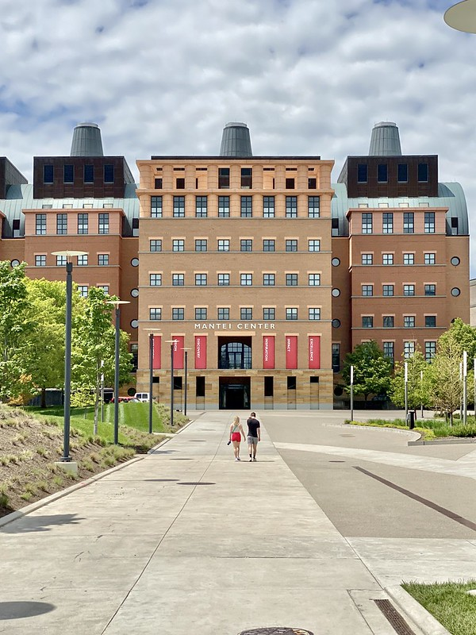

Mantei Engineering Research Center, home of the College of Engineering and Applied Science, on UC’s main campus. *Photo by Warren LeMay. License: CC BY-SA 2.0.*

The University of Cincinnati was founded in **1819** and today enrolls **~53,000** students across three campuses. Its Carnegie R1 designation reflects a sustained commitment to high-impact research.

- Birthplace of cooperative education (Herman Schneider, 1906)
- R1 Carnegie classification — Very High Research Activity
- SDRC faculty spin-off became the foundation of Siemens Digital Industries Software
- Albert Sabin (UC) developed the first oral polio vaccine
- George Rieveschl (UC) invented Benadryl — the first antihistamine
- CEAS Cleanroom: a regional hub for semiconductor & micro/nano fabrication R&D
- Research partnership with Thales (defense, space, aeronautics) at Digital Futures
- GE Aerospace Next Engineers program hosted by UC through 2028
- NSF ranked UC #31 among public universities for research activity (2022–23 survey)

Herman Schneider’s “Cincinnati Plan” — launched in 1906 from what is now CEAS — pioneered a model of paid, full-time work rotations integrated directly into degree programs. That same ethos shapes how MMIE faculty approach research partnerships today: industry sponsors don’t just write checks, they co-create knowledge alongside students and faculty.

## Research in MMIE

Research in MMIE is organized around **6 major centers** and more than a dozen specialized laboratories. Signature themes include:

**Advanced Manufacturing** — MMIE is a regional leader in additive manufacturing research, including gas-phase alloying and sintering kinetics of 3D-printed metals and magnetic-field assisted laser metal deposition of oriented nickel superalloys. The college’s Digital Fabrication Laboratory supports both fundamental science and technology-transfer projects.

**Materials Characterization & Modeling** — High-resolution TEM, thermomechanical testing, electron backscatter diffraction, CALPHAD-based thermodynamic and kinetic modeling, and phase-field simulation capabilities allow faculty to study materials from the atomic scale up.

**Energy & Nuclear Materials** — Growing investments in high temperature alloy performance, metals process modeling, rare-earth-free magnet materials, and energy device materials connect MMIE to national laboratory, Department of Defense, and Department of Energy priorities.

**Smart Systems & Industry 4.0/5.0** — Faculty in dynamics, controls, structural health monitoring, and data analytics partner with regional manufacturers to deploy AI-driven inspection and process-optimization tools.

## Degree Programs

| Program |
| --- |
| B.S. Mechanical Engineering |
| B.S. Industrial & Systems Engineering |
| B.S. Mechanical Engineering Technology |
| Minor in Materials Science & Engineering |
| M.Eng. Mechanical Engineering (coursework) |
| M.S. Mechanical Engineering (thesis) |
| M.Eng. Materials Science & Engineering (coursework) |
| M.S. Materials Science & Engineering (thesis) |
| Ph.D. Mechanical Engineering |
| Ph.D. Materials Science & Engineering |

Graduate students in MMIE have access to the full breadth of CEAS facilities, a rich seminar series, and UC’s professional-development infrastructure. Many research assistantships are funded through external grants from NSF, DOE, DOD/AFRL, and industrial sponsors.

## Industry & Sponsor Engagement

> **Current and recent industrial partners include:** `GE Aerospace` `Siemens Digital Industries` `Thales` `Procter & Gamble` `Cincinnati Incorporated` `Materion` `Air Force Research Laboratory (AFRL)` `NASA`

MMIE’s industrial engagement model mirrors the broader UC co-op philosophy: deep, long-term relationships rather than transactional sponsorships. Mechanisms for engagement include:

- **Sponsored Research Agreements** — fund specific graduate student projects with IP rights negotiated upfront.
- **Consortium Research** — cost-shared access to pre-competitive results (contact the CEAS Research Office).
- **Student Talent Pipeline** — co-op rotations and direct-hire relationships with graduating M.S./Ph.D. students.
- **Shared-Use Facilities** — external access to the Cleanroom, characterization instruments, and computational clusters.

> “Our research agenda at the University of Cincinnati has grown incredibly, thanks to the talents of our faculty researchers and their passion for discovery.”  
> — **Neville Pinto, PhD**, President, University of Cincinnati

For sponsorship inquiries, contact the [CEAS Research Office](https://www.ceas.uc.edu/research.html).

## Cincinnati: A City Built for Engineers

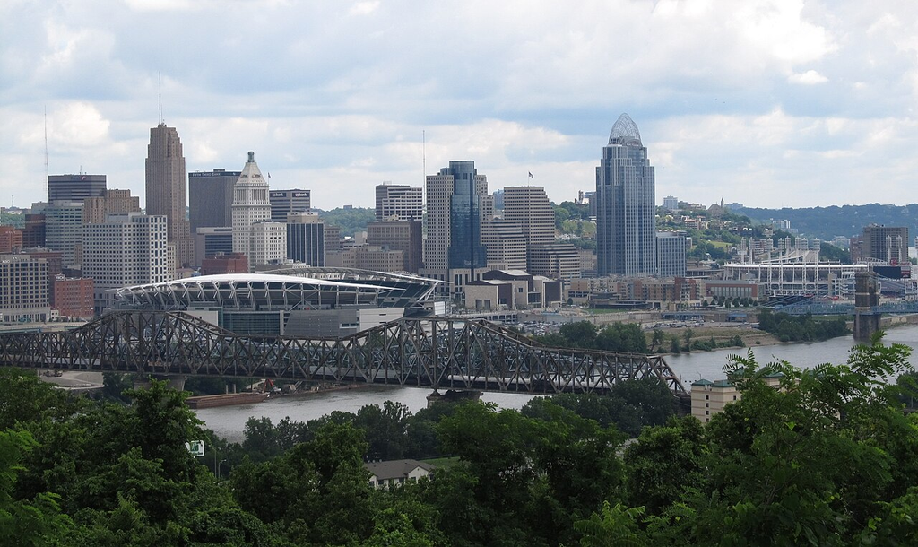

Cincinnati viewed from Devou Park in Covington, KY. *Photo by Ynsalh. License: CC BY-SA 4.0.*

Cincinnati is home to a dense cluster of advanced-manufacturing and aerospace companies, giving MMIE researchers unmatched access to real-world problems and industry networking. The city’s cost of living is well below coastal research hubs, and students’ co-op earnings substantially offset the costs of tuition.

## Connect with MMIE

[output not shown]